# Testing the `usmap` Package

Rebecca Amodeo

6/12/2021

## This is How it Started

I wanted to map data from the “Incarceration Trends” [#tidytuesday project](https://github.com/rfordatascience/tidytuesday/tree/master/data/2019/2019-01-22) on a geographic map after being inspired by a more traditional graphical representation from [lizwillow on GitHub](https://github.com/lizwillow/TidyTuesday/blob/master/TT.2019.01.21/week20190121.Rmd). In addition to the clarity in the data vis, I also like to explore national and state-level data through comparing national metrics to the states I have lived in.

I ran into issues with the map packages I had used previously, so I got the idea to start with a new-to-me package as a way to help my brain detach from whatever it was that kept me from getting what I wanted out of old code I had used for a few specific purposes. I thought I could pay better attention to detail if I knew I was learning a whole new package.

## Choose a Map Package

I chose `usmap` package because it includes capacity to map Alaska and Hawaii unlike some other map packages I have used before. Even though much of the mapping I do these days is centered on the state of Oregon, I think it’s good to practice a map package that has more than the contiguous 48. Download the `usmap` documentation at https://usmap.dev/.

## Map Template

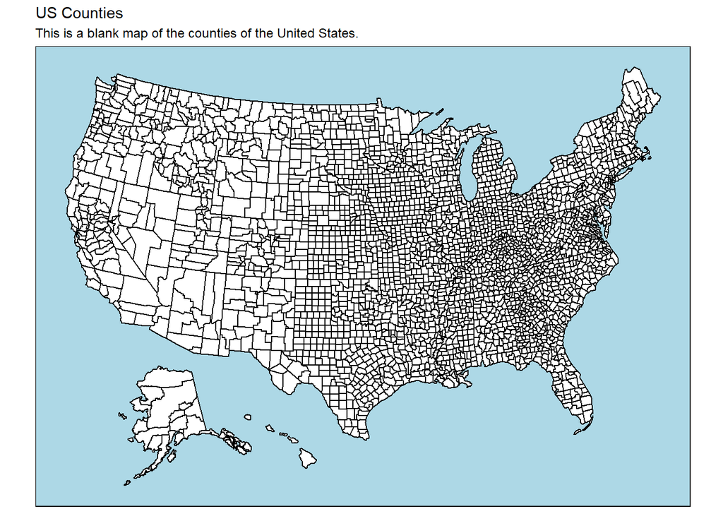

## Mapping Included Data

Using area data contained in the `usmap` package:

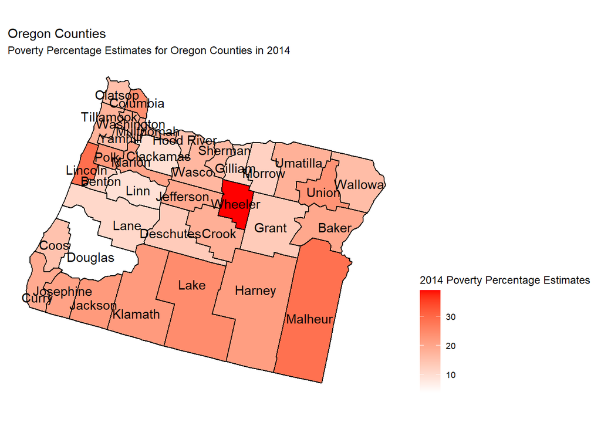

## More Data

I also wanted to map newer poverty rate data onto the county map using `usmap` package.

Documentation for 2019 poverty data from Small Area Income and Poverty Estimates (SAIPE) Program available [here](https://www.census.gov/programs-surveys/saipe.html).

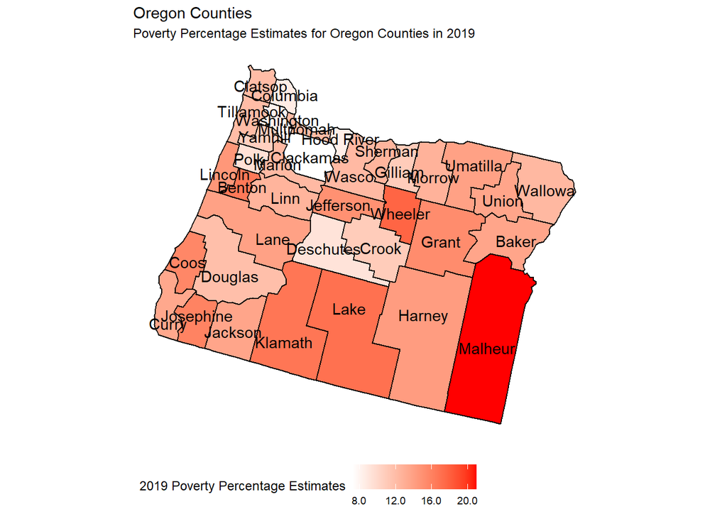

Let’s see if it’s that easy when I scale it up to map county rates of poverty onto the entire U.S. map.

In the first attempt, I removed the labels argument, so it defaults to `labels = FALSE`. I removed the `include =` argument, so all fifty (50) states show up on the map, and I adjusted the plot labs, so I wouldn’t get confused. The result? I got a map that only has state outlines. Worse, it had all states the same saturation of grey fill.

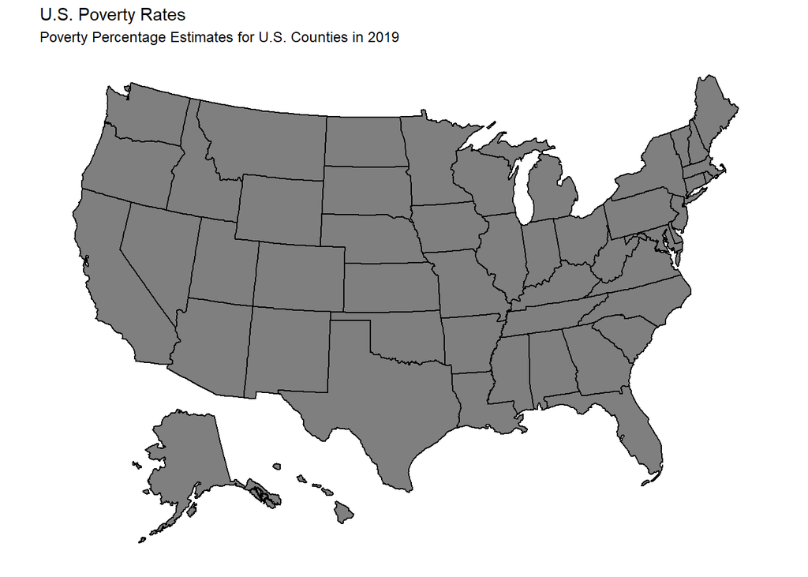

In the second attempt, I filtered out the `fips = 0`, which is for the entire U.S. and filtered out the fips with “000” in attempt to remove all the state totals. That did a pretty good job, but I noticed there are several county-like polygons that got swept up in the removed data which resulted in some counties with grey fill rather than a data-scaled fill.

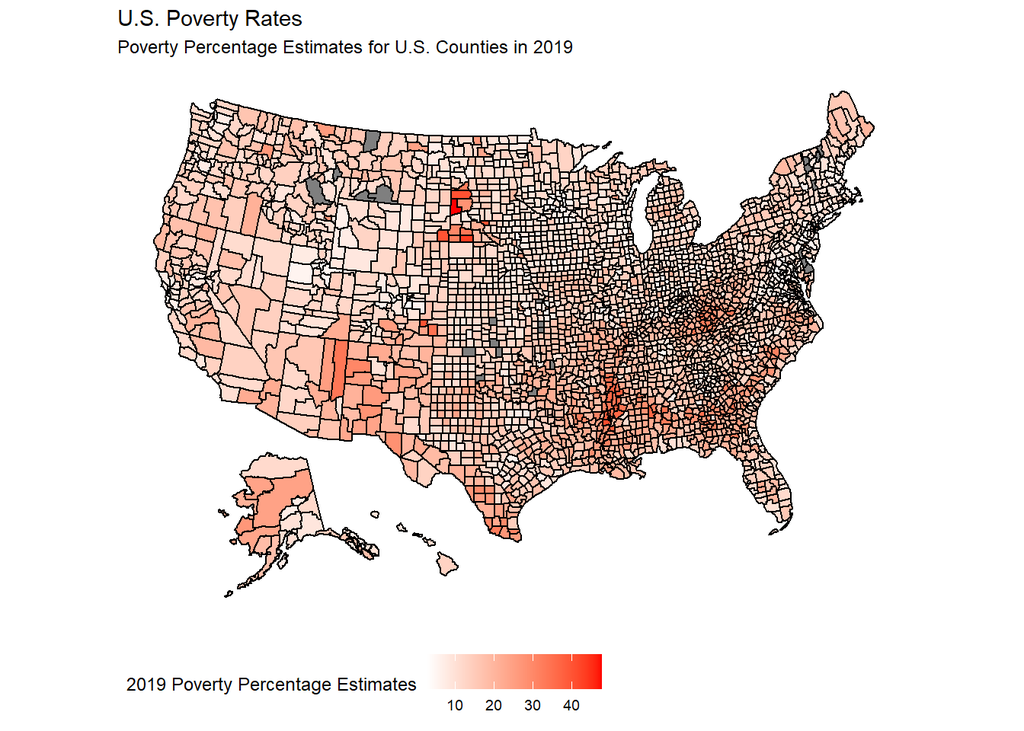

I got it in the third attempt where I only removed the the row where `fips == 0`.

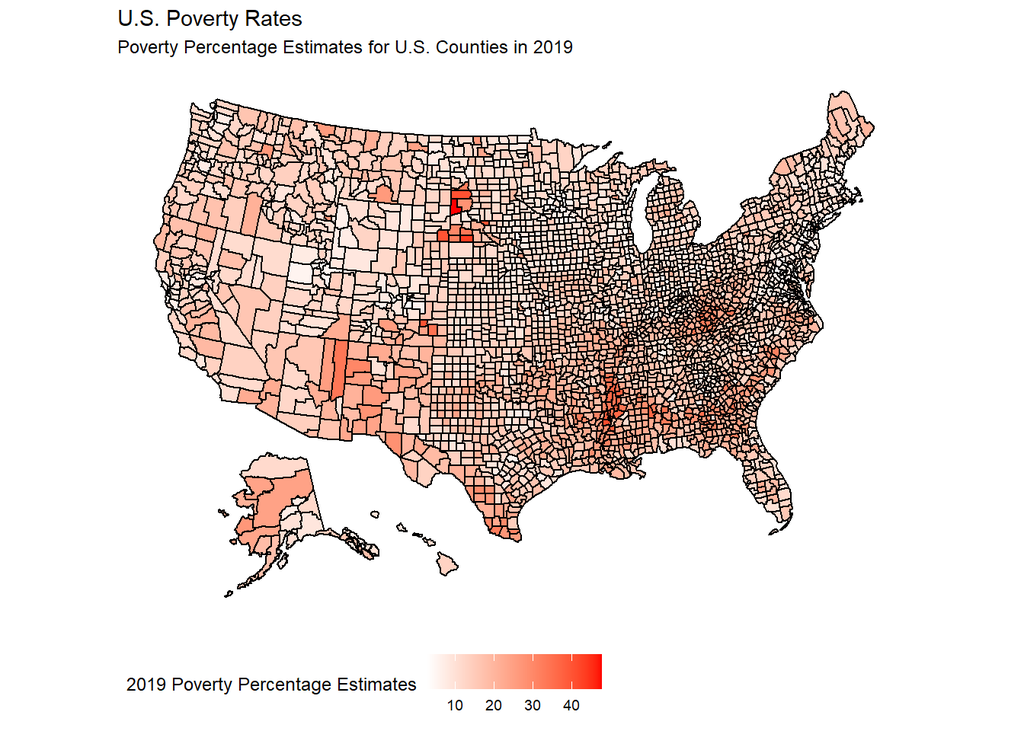

Success! Well, success enough to move on to my originally intended data.

But I’m tired, so I’ll get to that next week. I would like to get to it tomorrow because I’m excited about it, but I am in the midst of a move, so I expect I will be pretty well occupied.

## See the Code

The associated .Rmd file is available at https://github.com/RAAmodeo/r_examples/tree/master/usmap.